# Topic Modeling with Gensim (Python)

Topic Modeling is a technique to extract the hidden topics from large volumes of text. Latent Dirichlet Allocation(LDA) is a popular algorithm for topic modeling with excellent implementations in the Python’s Gensim package. The challenge, however, is *how to extract good quality of topics that are clear, segregated and meaningful.* This depends heavily on the quality of text preprocessing and the strategy of finding the optimal number of topics. This tutorial attempts to tackle both of these problems.

## Content

1. Introduction
2. Prerequisites – Download nltk stopwords and spacy model
3. Import Packages
4. What does LDA do?
5. Prepare Stopwords
6. Import Newsgroups Data
7. Remove emails and newline characters
8. Tokenize words and Clean-up text
9. Creating Bigram and Trigram Models
10. Remove Stopwords, Make Bigrams and Lemmatize
11. Create the Dictionary and Corpus needed for Topic Modeling
12. Building the Topic Model
13. View the topics in LDA model
14. Compute Model Perplexity and Coherence Score
15. Visualize the topics-keywords
16. Building LDA Mallet Model
17. How to find the optimal number of topics for LDA?
18. Finding the dominant topic in each sentence
19. Find the most representative document for each topic
20. Topic distribution across documents

## 1. Introduction

One of the primary applications of natural language processing is to automatically extract what topics people are discussing from large volumes of text. Some examples of large text could be feeds from social media, customer reviews of hotels, movies, etc, user feedbacks, news stories, e-mails of customer complaints etc.

Knowing what people are talking about and understanding their problems and opinions is highly valuable to businesses, administrators, political campaigns. And it’s really hard to manually read through such large volumes and compile the topics.

Thus is required an automated algorithm that can read through the text documents and automatically output the topics discussed.

I will be using the Latent Dirichlet Allocation (LDA) from Gensim package along with the Mallet’s implementation (via Gensim). Mallet has an efficient implementation of the LDA. It is known to run faster and gives better topics segregation.

We will also extract the volume and percentage contribution of each topic to get an idea of how important a topic is.

## 2. Prerequisites – Download nltk stopwords and spacy model

We will need the stopwords from NLTK and spacy’s en model for text pre-processing. Later, we will be using the spacy model for lemmatization.

Lemmatization is nothing but converting a word to its root word. For example: the lemma of the word ‘machines’ is ‘machine’. Likewise, ‘walking’ –> ‘walk’, ‘mice’ –> ‘mouse’ and so on.

```python
# Run in python console
import nltk; nltk.download('stopwords')

# Run in terminal or command prompt
!python -m spacy download en
```

[output not shown]

[output not shown]

## 3. Import Packages

The core packages used in this tutorial are `re`, `gensim`, `spacy` and `pyLDAvis`. Besides this we will also using `matplotlib`,`numpy` and `pandas` for data handling and visualization. Let’s import them.

```python
!pip install pyLDAvis
!pip install gensim
!pip install spacy==2.2.0
```

[output not shown]

[output not shown]

```python
import re
import numpy as np
import pandas as pd
from pprint import pprint

# Gensim
import gensim
import gensim.corpora as corpora
from gensim.utils import simple_preprocess
from gensim.models import CoherenceModel

# spacy for lemmatization
import spacy

# Plotting tools
import pyLDAvis
import pyLDAvis.gensim  # don't skip this
import matplotlib.pyplot as plt
%matplotlib inline

# Enable logging for gensim - optional
import logging
logging.basicConfig(format='%(asctime)s : %(levelname)s : %(message)s', level=logging.ERROR)

import warnings
warnings.filterwarnings("ignore",category=DeprecationWarning)
```

## 4. What does LDA do?

LDA’s approach to topic modeling is it considers each document as a collection of topics in a certain proportion. And each topic as a collection of keywords, again, in a certain proportion.

Once you provide the algorithm with the number of topics, all it does it to rearrange the topics distribution within the documents and keywords distribution within the topics to obtain a good composition of topic-keywords distribution.

When I say topic, what is it actually and how it is represented?

A topic is nothing but a collection of dominant keywords that are typical representatives. Just by looking at the keywords, you can identify what the topic is all about.

The following are key factors to obtaining good segregation topics:

1)The quality of text processing.

2)The variety of topics the text talks about.

3)The choice of topic modeling algorithm.

4)The number of topics fed to the algorithm.

5)The algorithms tuning parameters.

## 5. Prepare Stopwords

We have already downloaded the stopwords. Let's import them and make it available in `stop_words`.

```python
# NLTK Stop words
from nltk.corpus import stopwords
stop_words = stopwords.words('english')
stop_words.extend(['from', 'subject', 're', 'edu', 'use'])
```

## 6. Import Newsgroups Data

```python
# Import Dataset
text_file = "Reviews 2.csv"
df = pd.read_csv(text_file)
print(df["Review Text"].unique())
df.head()
```

```
['Very Best camera and chat app🔥👍👍'
 "I love love love this app🥰 its its amazingly easy to chat with your friends and it had really funny stuff so y'all should download this app"
 'Broken joke of an app. Nothing else to it' ...
 "Good app, obviously very popular. Only issue I have is that on a Samsung galaxy note 5, whenever you try to take a picture at night up close with the flash on the forward facing camera, it won't focus. Always comes out too bright, and then sometimes it freezes with the face camera and you can't ta…
 'This app gets worse and worse after each and every update. I have a S9 and the front camera quality was great until version 10.40.5.0. Since this update the quality is absolutely horrendous. Now I have to go back and find an old version of this app because snapchat does not listen to their own com…
 'Snapchat is great for texting. All my friends use it instead of facebook now, and it\'s faster than SMS on my phone. My one issue is the "Unfortunately, Snapchat has stopped" error, this comes up frequently if i try to add text to a snap. When this gets fixed i will change my rating to a 5!']
```

|  | Date | Rating | Helpful | Review Text |
| --- | --- | --- | --- | --- |
| 0 | 19-Nov-19 | 4 | 0 | Very Best camera and chat app🔥👍👍 |
| 1 | 19-Nov-19 | 5 | 0 | I love love love this app🥰 its its amazingly e... |
| 2 | 19-Nov-19 | 1 | 5 | Broken joke of an app. Nothing else to it |
| 3 | 19-Nov-19 | 5 | 0 | One of the best texting a call apps out there |
| 4 | 19-Nov-19 | 1 | 0 | Have to download it again and again so that th... |

## 7. Remove emails and newline characters

As you can see there are many emails, newline and extra spaces that is quite distracting. Let's get rid of them using [regular expressions](https://www.machinelearningplus.com/python/python-regex-tutorial-examples/).

```python
# Convert to list
data = df["Review Text"].astype(str).values.tolist()

# Remove Emails
data = [re.sub('\S*@\S*\s?', '', sent) for sent in data]

# Remove new line characters
data = [re.sub('\s+', ' ', sent) for sent in data]

# Remove distracting single quotes
data = [re.sub("\'"," ", sent) for sent in data]

pprint(data[:2])
```

```
['Very Best camera and chat app🔥👍👍',
 'I love love love this app🥰 its its amazingly easy to chat with your friends '
 'and it had really funny stuff so y all should download this app']
```

## 8. Tokenize words and Clean-up text

The sentences look better now, but you want to tokenize each sentence into a list of words, removing punctuations and unneccessary characters altogether.

Gensim's `simple_preprocess()` is great for this. Additionally I have set `deacc=True` to remove the punctuations.

```python
def sent_to_words(sentences):
    for sentence in sentences:
        yield(gensim.utils.simple_preprocess(str(sentence).encode('utf-8'), deacc=True))  # deacc=True removes punctuations

data_words = list(sent_to_words(data))
print(data_words[:1])
```

```
[['very', 'best', 'camera', 'and', 'chat', 'app']]
```

## 9. Create Bigram and Trigram Models

Bigrams are two words frequently occurring together in the document. Trigrams are 3 words frequently occurring.

Gensim's `Phrases` model can build and implement the bigrams, trigrams, quadgrams and more. The two important arguments to `Phrases` are `min_count` and `threshold`. The higher the values of these param, the harder it is for words to be combined to bigrams.

```python
# Build the bigram and trigram models
bigram = gensim.models.Phrases(data_words, min_count=5, threshold=100) # higher threshold fewer phrases.
trigram = gensim.models.Phrases(bigram[data_words], threshold=100)

# Faster way to get a sentence clubbed as a trigram/bigram
bigram_mod = gensim.models.phrases.Phraser(bigram)
trigram_mod = gensim.models.phrases.Phraser(trigram)

# See trigram example
print(trigram_mod[bigram_mod[data_words[0]]])
```

```
['very', 'best', 'camera', 'and', 'chat', 'app']
```

## 10. Remove Stopwords, Make Bigrams and Lemmatize

The bigrams model is ready. Let's define the functions to remove the stopwords, make bigrams and lemmatization and call them sequentially.

```python
# Define functions for stopwords, bigrams, trigrams and lemmatization
def remove_stopwords(texts):
    return [[word for word in simple_preprocess(str(doc)) if word not in stop_words] for doc in texts]

def make_bigrams(texts):
    return [bigram_mod[doc] for doc in texts]

def make_trigrams(texts):
    return [trigram_mod[bigram_mod[doc]] for doc in texts]

def lemmatization(texts, allowed_postags=['NOUN', 'ADJ', 'VERB', 'ADV']):
    """https://spacy.io/api/annotation"""
    texts_out = []
    for sent in texts:
        doc = nlp(" ".join(sent))
        texts_out.append([token.lemma_ for token in doc if token.pos_ in allowed_postags])
    return texts_out
```

Let’s call the functions in order.

```python
!pip install https://github.com/explosion/spacy-models/releases/download/en_core_web_sm-2.2.0/en_core_web_sm-2.2.0.tar.gz
```

```python
!python -m spacy download en_core_web_sm
```

```
[+] Download and installation successful
You can now load the model via spacy.load('en_core_web_sm')
```

```python
# Remove Stop Words
data_words_nostops = remove_stopwords(data_words)

# Form Bigrams
data_words_bigrams = make_bigrams(data_words_nostops)

# Initialize spacy 'en' model, keeping only tagger component (for efficiency)
import en_core_web_sm
nlp = en_core_web_sm.load()

#nlp = spacy.load('en_core_web_sm', disable=['parser', 'ner'])

# Do lemmatization keeping only noun, adj, vb, adv
data_lemmatized = lemmatization(data_words_bigrams, allowed_postags=['NOUN', 'ADJ', 'VERB', 'ADV'])

print(data_lemmatized[:1])
```

```
[['camera']]
```

## 11. Create the Dictionary and Corpus needed for Topic Modeling

The two main inputs to the LDA topic model are the dictionary(`id2word`) and the corpus. Let's create them.

```python
# Create Dictionary
id2word = corpora.Dictionary(data_lemmatized)

# Create Corpus
texts = data_lemmatized

# Term Document Frequency
corpus = [id2word.doc2bow(text) for text in texts]

# View
print(corpus[:1])
```

```
[[(0, 1)]]
```

Gensim creates a unique id for each word in the document. The produced corpus shown above is a mapping of (word_id, word_frequency).

This is used as the input by the LDA model.

If you want to see what word a given id corresponds to, pass the id as a key to the dictionary.

```python
id2word[0]
```

```
'camera'
```

Or, you can see a human readable form of the corpus itself.

```python
corpus[:1][0][:10]
```

```
[(0, 1)]
```

```python
# Human readable format of corpus (term-frequency)
[[(id2word[id], freq) for id, freq in cp] for cp in corpus[:1]]
```

```
[[('camera', 1)]]
```

Alright, without digressing further let's jump back on track with the next step: Building the topic model.

## 12. Building the Topic Model

We have everything required to train the LDA model. In addition to the corpus and dictionary, you need to provide the number of topics as well.

Apart from that, `alpha` and `eta` are hyperparameters that affect sparsity of the topics. According to the gensim docs, both defaults to 1.0/num_topics prior.

`chunksize` is the number of documents to be used in each training chunk. `update_every` determines how often the model parameters should be updated and `passes` is the total number of training passes.

```python
# Build LDA model
lda_model = gensim.models.ldamodel.LdaModel(corpus=corpus,
                                           id2word=id2word,
                                           num_topics=20,
                                           random_state=100,
                                           update_every=1,
                                           chunksize=100,
                                           passes=10,
                                           alpha='auto',
                                           per_word_topics=True)
```

## 13. View the topics in LDA model

The above LDA model is built with 20 different topics where each topic is a combination of keywords and each keyword contributes a certain weightage to the topic.

You can see the keywords for each topic and the weightage(importance) of each keyword using `lda_model.print_topics()` as shown next.

```python
# Print the Keyword in the 10 topics
pprint(lda_model.print_topics())
doc_lda = lda_model[corpus]
```

```
[(0,
  '0.221*"really" + 0.197*"problem" + 0.154*"save" + 0.108*"much" + '
  '0.103*"well" + 0.084*"close" + 0.032*"sure" + 0.029*"have" + 0.028*"like" + '
  '0.018*"notice"'),
 (1,
  '0.292*"go" + 0.208*"great" + 0.138*"know" + 0.124*"feature" + 0.053*"play" '
  '+ 0.042*"image" + 0.035*"game" + 0.028*"zoom" + 0.024*"buggy" + '
  '0.021*"reply"'),
 (2,
  '0.188*"update" + 0.140*"send" + 0.137*"fix" + 0.121*"work" + 0.113*"even" + '
  '0.078*"message" + 0.064*"say" + 0.031*"stop" + 0.020*"fine" + '
  '0.016*"terrible"'),
 (3,
  '0.239*"still" + 0.166*"delete" + 0.090*"recently" + 0.069*"different" + '
  '0.057*"person" + 0.056*"whole" + 0.055*"glitch" + 0.046*"properly" + '
  '0.044*"datum" + 0.035*"pop"'),
 (4,
  '0.263*"snap" + 0.206*"story" + 0.093*"load" + 0.079*"chat" + 0.066*"second" '
  '+ 0.060*"show" + 0.027*"late" + 0.023*"hour" + 0.023*"type" + '
  '0.022*"watch"'),
 (5,
  '0.452*"video" + 0.156*"slow" + 0.101*"last" + 0.088*"view" + '
  '0.057*"experience" + 0.045*"super" + 0.031*"family" + 0.028*"unable" + '
  '0.013*"recording" + 0.006*"serious"'),
 (6,
  '0.674*"amazing" + 0.067*"min" + 0.000*"post" + 0.000*"user" + '
  '0.000*"social_media" + 0.000*"face" + 0.000*"wait" + 0.000*"focus" + '
  '0.000*"unhealthy" + 0.000*"put"'),
 (7,
  '0.198*"back" + 0.171*"never" + 0.137*"come" + 0.118*"star" + 0.099*"minute" '
  '+ 0.093*"call" + 0.052*"disappear" + 0.043*"absolutely" + 0.029*"rate" + '
  '0.020*"improvement"'),
 (8,
  '0.417*"good" + 0.217*"need" + 0.141*"ever" + 0.132*"text" + 0.046*"far" + '
  '0.011*"opinion" + 0.000*"post" + 0.000*"user" + 0.000*"lag" + '
  '0.000*"version"'),
 (9,
  '0.298*"get" + 0.199*"new" + 0.077*"notification" + 0.074*"happen" + '
  '0.046*"turn" + 0.045*"however" + 0.041*"download" + 0.033*"longer" + '
  '0.031*"overall" + 0.021*"setting"'),
```

[output cut: 24 more lines]

```
 (16,
  '0.344*"take" + 0.217*"picture" + 0.106*"want" + 0.078*"sometimes" + '
  '0.049*"option" + 0.045*"account" + 0.037*"right" + 0.032*"pretty" + '
  '0.026*"allow" + 0.021*"big"'),
 (17,
  '0.345*"love" + 0.324*"filter" + 0.125*"bug" + 0.083*"fun" + 0.043*"force" + '
  '0.028*"awesome" + 0.027*"funny" + 0.000*"post" + 0.000*"user" + '
  '0.000*"face"'),
 (18,
  '0.196*"make" + 0.191*"android" + 0.143*"see" + 0.112*"people" + 0.095*"bad" '
  '+ 0.028*"one" + 0.028*"tell" + 0.026*"sound" + 0.026*"wish" + 0.022*"less"'),
 (19,
  '0.325*"camera" + 0.149*"quality" + 0.108*"look" + 0.080*"record" + '
  '0.075*"start" + 0.067*"device" + 0.058*"help" + 0.030*"flash" + '
  '0.022*"awful" + 0.018*"front"')]
```

How to interpret this?

The weights reflect how important a keyword is to that topic.

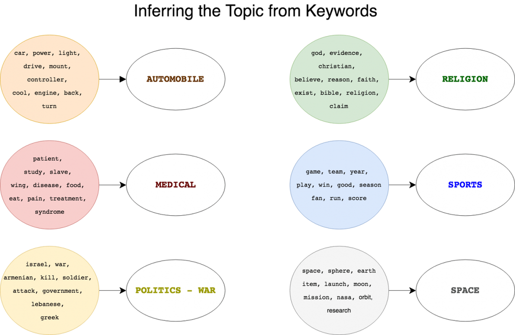

Inferring Topic from Keywords

## 14. Compute Model Perplexity and Coherence Score

Model perplexity and [topic coherence](https://rare-technologies.com/what-is-topic-coherence/) provide a convenient measure to judge how good a given topic model is. In my experience, topic coherence score, in particular, has been more helpful.

```python
# Compute Perplexity
print('\nPerplexity: ', lda_model.log_perplexity(corpus))  # a measure of how good the model is. lower the better.

# Compute Coherence Score
coherence_model_lda = CoherenceModel(model=lda_model, texts=data_lemmatized, dictionary=id2word, coherence='c_v')
coherence_lda = coherence_model_lda.get_coherence()
print('\nCoherence Score: ', coherence_lda)
```

```
Perplexity:  -12.368517537318017

Coherence Score:  0.37476126229923323
```

## 15. Visualize the topics-keywords

Now that the LDA model is built, the next step is to examine the produced topics and the associated keywords. There is no better tool than pyLDAvis package’s interactive chart and is designed to work well with jupyter notebooks.

```python
# Visualize the topics
pyLDAvis.enable_notebook()
vis = pyLDAvis.gensim.prepare(lda_model, corpus, id2word)
vis
```

[interactive chart not shown]

So how to infer pyLDAvis’s output?

Each bubble on the left-hand side plot represents a topic. The larger the bubble, the more prevalent is that topic.

A good topic model will have fairly big, non-overlapping bubbles scattered throughout the chart instead of being clustered in one quadrant.

A model with too many topics, will typically have many overlaps, small sized bubbles clustered in one region of the chart.

Alright, if you move the cursor over one of the bubbles, the words and bars on the right-hand side will update. These words are the salient keywords that form the selected topic.

We have successfully built a good looking topic model.

Upnext, we will improve upon this model by using Mallet’s version of LDA algorithm and then we will focus on how to arrive at the optimal number of topics given any large corpus of text.

## 16. Building LDA Mallet Model

So far you have seen Gensim’s inbuilt version of the LDA algorithm. Mallet’s version, however, often gives a better quality of topics.

Gensim provides a wrapper to implement Mallet's LDA from within gensim itself. You only need to [download](http://mallet.cs.umass.edu/dist/mallet-2.0.8.zip) the zipfile, unzip it and provide the path to mallet in the unzipped directory to `gensim.models.wrappers.LdaMallet`. See how I have done this below.

```python
import os
#os.environ.update({'MALLET_HOME':r'C:/Users/Lenovo/Desktop/mallet-2.0.8'})

from io import BytesIO
from urllib.request import urlopen
from zipfile import ZipFile
zipurl = 'http://mallet.cs.umass.edu/dist/mallet-2.0.8.zip'
with urlopen(zipurl) as zipresp:
    with ZipFile(BytesIO(zipresp.read())) as zfile:
        zfile.extractall(os.getcwd())
os.environ['MALLET_HOME'] = os.getcwd() + '/mallet-2.0.8'
```

```python
os.getcwd()
```

```
'C:\\Users\\Kunja\\Documents\\BacklogMagic'
```

```python
## Download File: http://mallet.cs.umass.edu/dist/mallet-2.0.8.zip
mallet_path = os.getcwd() + '/mallet-2.0.8/bin/mallet' # update this path
print(mallet_path)
ldamallet = gensim.models.wrappers.LdaMallet(mallet_path, corpus=corpus, num_topics=20, id2word=id2word)
```

```
C:\Users\Kunja\Documents\BacklogMagic/mallet-2.0.8/bin/mallet
```

```python
# Show Topics
pprint(ldamallet.show_topics(formatted=False))

# Compute Coherence Score
coherence_model_ldamallet = CoherenceModel(model=ldamallet, texts=data_lemmatized, dictionary=id2word, coherence='c_v')
coherence_ldamallet = coherence_model_ldamallet.get_coherence()
print('\nCoherence Score: ', coherence_ldamallet)
```

[output not shown]

[output cut: 57 more lines]

[output not shown]

## 17. How to find the optimal number of topics for LDA?

My approach to finding the optimal number of topics is to build many LDA models with different values of number of topics (k) and pick the one that gives the highest coherence value.

Choosing a ‘k’ that marks the end of a rapid growth of topic coherence usually offers meaningful and interpretable topics. Picking an even higher value can sometimes provide more granular sub-topics.

If you see the same keywords being repeated in multiple topics, it’s probably a sign that the ‘k’ is too large.

The `compute_coherence_values()` (see below) trains multiple LDA models and provides the models and their corresponding coherence scores.

```python
def compute_coherence_values(dictionary, corpus, texts, limit, start=2, step=3):
    """
    Compute c_v coherence for various number of topics

    Parameters:
    ----------
    dictionary : Gensim dictionary
    corpus : Gensim corpus
    texts : List of input texts
    limit : Max num of topics

    Returns:
    -------
    model_list : List of LDA topic models
    coherence_values : Coherence values corresponding to the LDA model with respective number of topics
    """
    coherence_values = []
    model_list = []
    for num_topics in range(start, limit, step):
        model = gensim.models.wrappers.LdaMallet(mallet_path, corpus=corpus, num_topics=num_topics, id2word=id2word)
        model_list.append(model)
        coherencemodel = CoherenceModel(model=model, texts=texts, dictionary=dictionary, coherence='c_v')
        coherence_values.append(coherencemodel.get_coherence())

    return model_list, coherence_values
```

```python
# Can take a long time to run.
model_list, coherence_values = compute_coherence_values(dictionary=id2word, corpus=corpus, texts=data_lemmatized, start=2, limit=40, step=6)
```

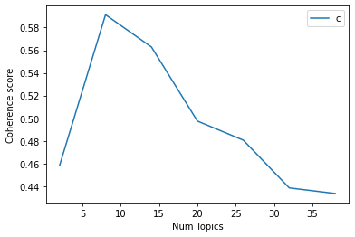

```python
# Show graph
limit=40; start=2; step=6;
x = range(start, limit, step)
plt.plot(x, coherence_values)
plt.xlabel("Num Topics")
plt.ylabel("Coherence score")
plt.legend(("coherence_values"), loc='best')
plt.show()
```

```python
# Print the coherence scores
for m, cv in zip(x, coherence_values):
    print("Num Topics =", m, " has Coherence Value of", round(cv, 4))
```

```
Num Topics = 2  has Coherence Value of 0.4583
Num Topics = 8  has Coherence Value of 0.5914
Num Topics = 14  has Coherence Value of 0.5628
Num Topics = 20  has Coherence Value of 0.4975
Num Topics = 26  has Coherence Value of 0.4806
Num Topics = 32  has Coherence Value of 0.4385
Num Topics = 38  has Coherence Value of 0.4336
```

```python
from operator import itemgetter

num_topics = max(zip(x, coherence_values),key=itemgetter(1))[0]

model_index = x.index(num_topics)
```

```python
# Select the model and print the topics
optimal_model = model_list[model_index]
model_topics = optimal_model.show_topics(formatted=False)
pprint(optimal_model.print_topics(num_words=10))
```

```
[(0,
  '0.072*"problem" + 0.046*"fix" + 0.042*"change" + 0.038*"give" + 0.035*"log" '
  '+ 0.033*"account" + 0.032*"day" + 0.028*"star" + 0.028*"back" + '
  '0.025*"delete"'),
 (1,
  '0.105*"video" + 0.104*"story" + 0.065*"fix" + 0.032*"bug" + 0.032*"slow" + '
  '0.031*"screen" + 0.024*"view" + 0.023*"long" + 0.022*"annoying" + '
  '0.020*"play"'),
 (2,
  '0.156*"snap" + 0.153*"send" + 0.096*"message" + 0.055*"load" + 0.054*"chat" '
  '+ 0.042*"notification" + 0.039*"show" + 0.020*"issue" + 0.016*"receive" + '
  '0.016*"fail"'),
 (3,
  '0.198*"update" + 0.045*"save" + 0.043*"picture" + 0.032*"photo" + '
  '0.031*"make" + 0.030*"feature" + 0.025*"memory" + 0.023*"option" + '
  '0.021*"anymore" + 0.019*"find"'),
 (4,
  '0.096*"camera" + 0.059*"android" + 0.044*"phone" + 0.040*"bad" + '
  '0.034*"quality" + 0.033*"issue" + 0.028*"picture" + 0.025*"user" + '
  '0.016*"focus" + 0.015*"device"'),
 (5,
  '0.144*"filter" + 0.138*"friend" + 0.138*"love" + 0.045*"great" + '
  '0.041*"fun" + 0.039*"amazing" + 0.033*"talk" + 0.031*"text" + 0.027*"call" '
  '+ 0.022*"face"'),
 (6,
  '0.147*"good" + 0.079*"app" + 0.064*"people" + 0.061*"make" + 0.049*"thing" '
  '+ 0.043*"add" + 0.038*"great" + 0.035*"post" + 0.025*"lot" + 0.014*"nice"'),
 (7,
  '0.133*"work" + 0.125*"app" + 0.105*"time" + 0.061*"phone" + 0.060*"open" + '
  '0.037*"crash" + 0.033*"stop" + 0.027*"close" + 0.023*"freeze" + '
  '0.021*"fix"')]
```

Those were the topics for the chosen LDA model.

## 18. Finding the dominant topic in each sentence

One of the practical application of topic modeling is to determine what topic a given document is about.

To find that, we find the topic number that has the highest percentage contribution in that document.

The `format_topics_sentences()` function below nicely aggregates this information in a presentable table.

```python
def format_topics_sentences(ldamodel=lda_model, corpus=corpus, texts=data):
    # Init output
    sent_topics_df = pd.DataFrame()

    # Get main topic in each document
    for i, row in enumerate(ldamodel[corpus]):
        row = sorted(row, key=lambda x: (x[1]), reverse=True)
        # Get the Dominant topic, Perc Contribution and Keywords for each document
        for j, (topic_num, prop_topic) in enumerate(row):
            if j == 0:  # => dominant topic
                wp = ldamodel.show_topic(topic_num)
                topic_keywords = ", ".join([word for word, prop in wp])
                sent_topics_df = sent_topics_df.append(pd.Series([int(topic_num), round(prop_topic,4), topic_keywords]), ignore_index=True)
            else:
                break
    sent_topics_df.columns = ['Dominant_Topic', 'Perc_Contribution', 'Topic_Keywords']

    # Add original text to the end of the output
    contents = pd.Series(texts)
    sent_topics_df = pd.concat([sent_topics_df, contents], axis=1)
    return(sent_topics_df)


df_topic_sents_keywords = format_topics_sentences(ldamodel=optimal_model, corpus=corpus, texts=data)

# Format
df_dominant_topic = df_topic_sents_keywords.reset_index()
df_dominant_topic.columns = ['Document_No', 'Dominant_Topic', 'Topic_Perc_Contrib', 'Keywords', 'Text']

# Show
df_dominant_topic.head(10)
```

|  | Document_No | Dominant_Topic | Topic_Perc_Contrib | Keywords | Text |
| --- | --- | --- | --- | --- | --- |
| 0 | 0 | 4.0 | 0.1422 | camera, android, phone, bad, quality, issue, p... | Very Best camera and chat app🔥👍👍 |
| 1 | 1 | 5.0 | 0.1958 | filter, friend, love, great, fun, amazing, tal... | I love love love this app🥰 its its amazingly e... |
| 2 | 2 | 1.0 | 0.1394 | video, story, fix, bug, slow, screen, view, lo... | Broken joke of an app. Nothing else to it |
| 3 | 3 | 5.0 | 0.1507 | filter, friend, love, great, fun, amazing, tal... | One of the best texting a call apps out there |
| 4 | 4 | 0.0 | 0.1379 | problem, fix, change, give, log, account, day,... | Have to download it again and again so that th... |
| 5 | 5 | 7.0 | 0.1892 | work, app, time, phone, open, crash, stop, clo... | Constantly just crashes my phone the moment I ... |
| 6 | 6 | 3.0 | 0.1623 | update, save, picture, photo, make, feature, m... | I absolulety like snapchat they just need to u... |
| 7 | 7 | 7.0 | 0.1500 | work, app, time, phone, open, crash, stop, clo... | All is Good but the export pic is not working ... |
| 8 | 8 | 6.0 | 0.1431 | good, app, people, make, thing, add, great, po... | best app for stories... |
| 9 | 9 | 5.0 | 0.1416 | filter, friend, love, great, fun, amazing, tal... | Love it jus wish u could tell when others was ... |

## 19. Find the most representative document for each topic

Sometimes just the topic keywords may not be enough to make sense of what a topic is about. So, to help with understanding the topic, you can find the documents a given topic has contributed to the most and infer the topic by reading that document. Whew!!

```python
# Group top 5 sentences under each topic
sent_topics_sorteddf_mallet = pd.DataFrame()

sent_topics_outdf_grpd = df_topic_sents_keywords.groupby('Dominant_Topic')

for i, grp in sent_topics_outdf_grpd:
    sent_topics_sorteddf_mallet = pd.concat([sent_topics_sorteddf_mallet,
                                             grp.sort_values(['Perc_Contribution'], ascending=[0]).head(1)],
                                            axis=0)

# Reset Index
sent_topics_sorteddf_mallet.reset_index(drop=True, inplace=True)

# Format
sent_topics_sorteddf_mallet.columns = ['Topic_Num', "Topic_Perc_Contrib", "Keywords", "Text"]

# Show
sent_topics_sorteddf_mallet.head()
```

|  | Topic_Num | Topic_Perc_Contrib | Keywords | Text |
| --- | --- | --- | --- | --- |
| 0 | 0.0 | 0.3656 | problem, fix, change, give, log, account, day,... | I don t know what s wrong with this app but I ... |
| 1 | 1.0 | 0.3885 | video, story, fix, bug, slow, screen, view, lo... | I actually love snapchat but I m sick of the a... |
| 2 | 2.0 | 0.3270 | snap, send, message, load, chat, notification,... | Never had any problems with it before but thes... |
| 3 | 3.0 | 0.3254 | update, save, picture, photo, make, feature, m... | HATE this new update. it is TRASH! It needs to... |
| 4 | 4.0 | 0.4151 | camera, android, phone, bad, quality, issue, p... | Unusable on 2018 MotoX4/ Oreo8 - Freezes, cras... |

## 20. Topic distribution across documents

```python
# Number of Documents for Each Topic
topic_counts = df_topic_sents_keywords['Dominant_Topic'].value_counts()

# Percentage of Documents for Each Topic
topic_contribution = round(topic_counts/topic_counts.sum(), 4)

# Topic Number and Keywords
topic_num_keywords = df_topic_sents_keywords[['Dominant_Topic', 'Topic_Keywords']]

# Concatenate Column wise
df_dominant_topics = pd.concat([topic_num_keywords, topic_counts, topic_contribution], axis=1)

# Change Column names
df_dominant_topics.columns = ['Dominant_Topic', 'Topic_Keywords', 'Num_Documents', 'Perc_Documents']

# Show
df_dominant_topics.head(20)
```

|  | Dominant_Topic | Topic_Keywords | Num_Documents | Perc_Documents |
| --- | --- | --- | --- | --- |
| 0.0 | 4.0 | camera, android, phone, bad, quality, issue, p... | 4247.0 | 0.1292 |
| 1.0 | 5.0 | filter, friend, love, great, fun, amazing, tal... | 3920.0 | 0.1192 |
| 2.0 | 1.0 | video, story, fix, bug, slow, screen, view, lo... | 4412.0 | 0.1342 |
| 3.0 | 5.0 | filter, friend, love, great, fun, amazing, tal... | 3469.0 | 0.1055 |
| 4.0 | 0.0 | problem, fix, change, give, log, account, day,... | 3741.0 | 0.1138 |
| 5.0 | 7.0 | work, app, time, phone, open, crash, stop, clo... | 6295.0 | 0.1915 |
| 6.0 | 3.0 | update, save, picture, photo, make, feature, m... | 3218.0 | 0.0979 |
| 7.0 | 7.0 | work, app, time, phone, open, crash, stop, clo... | 3573.0 | 0.1087 |
| 8.0 | 6.0 | good, app, people, make, thing, add, great, po... | NaN | NaN |
| 9.0 | 5.0 | filter, friend, love, great, fun, amazing, tal... | NaN | NaN |
| 10.0 | 5.0 | filter, friend, love, great, fun, amazing, tal... | NaN | NaN |
| 11.0 | 0.0 | problem, fix, change, give, log, account, day,... | NaN | NaN |
| 12.0 | 5.0 | filter, friend, love, great, fun, amazing, tal... | NaN | NaN |
| 13.0 | 2.0 | snap, send, message, load, chat, notification,... | NaN | NaN |
| 14.0 | 5.0 | filter, friend, love, great, fun, amazing, tal... | NaN | NaN |
| 15.0 | 2.0 | snap, send, message, load, chat, notification,... | NaN | NaN |
| 16.0 | 2.0 | snap, send, message, load, chat, notification,... | NaN | NaN |
| 17.0 | 7.0 | work, app, time, phone, open, crash, stop, clo... | NaN | NaN |
| 18.0 | 2.0 | snap, send, message, load, chat, notification,... | NaN | NaN |
| 19.0 | 5.0 | filter, friend, love, great, fun, amazing, tal... | NaN | NaN |

## 21. Conclusion

We started with understanding what topic modeling can do. We built a basic topic model using Gensim’s LDA and visualize the topics using pyLDAvis. Then we built mallet’s LDA implementation. You saw how to find the optimal number of topics using coherence scores and how you can come to a logical understanding of how to choose the optimal model.

Finally we saw how to aggregate and present the results to generate insights that may be in a more actionable.

Hope you enjoyed reading this. I would appreciate if you leave your thoughts in the comments section below.

Edit: I see some of you are experiencing errors while using the LDA Mallet and I don’t have a solution for some of the issues. So, I’ve implemented a workaround and more useful [topic model visualizations](https://www.machinelearningplus.com/nlp/topic-modeling-visualization-how-to-present-results-lda-models/). Hope you will find it helpful.